# Reproducible Research - Project Assignment 1

Sai krishnan

Saturday, October 18, 2014

## Dataset and assignment summary

The dataset consists of two months of activity data from an anonymous individual collected during the months of October and November, 2012 and include the number of steps taken in 5 minute intervals each day.

## R code to answer the questions

### Instructions for loading the dataset

Please load the dataset to your R working directory for the following code to execute correctly.

### R code to answer question 1

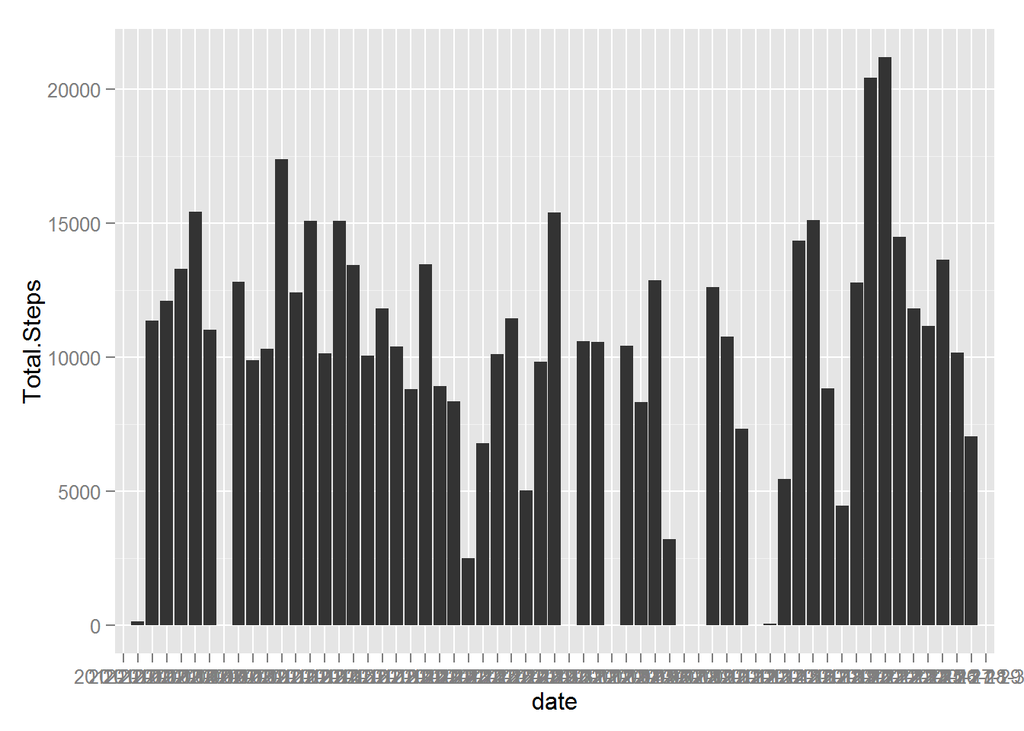

```r
library(knitr)
library(ggplot2)
library(plyr)
library(lubridate)
# Load the activity dataset as a dataframe
activityData <- as.data.frame(read.csv("activity.csv"))
# Prepare a histogram of the steps. Mising (NA) values are ignored.
totalSteps <- ddply(activityData,.(date), summarize, Total.Steps=sum(steps))
qplot(x=date,y=Total.Steps,data=totalSteps,geom="bar",
                 stat="identity")
```

```r
# Compute mean of total steps taken per day, removing NAs for a numeric result
mean(totalSteps$Total.Steps, na.rm=TRUE)
```

```
## [1] 10766.19
```

```r
# Compute median of total steps taken each day, removing NAs for a numeric result
median(totalSteps$Total.Steps,na.rm=TRUE)
```

```
## [1] 10765
```

### Strategy to impute missing values

We see that there are 2304 NA values in the steps variable of our activity dataset.

We will adopt a strategy to replace NA values by the mean values of steps in the corresponding 5 minute intervals across the days. For example: a NA value in the beginning of the day (interval value ‘0’) would be replaced by the mean value of the steps taken during the beginning of all the days (interval value ‘0’). A new dataset with imputed values is created in the following piece of R code.

```r
# Replace NAs with mean values grouped by intervals in a day
activityDataNew <- ddply(activityData, .(interval), function(df) {df$steps[is.na(df$steps)] <- mean(df$steps, na.rm=TRUE); return(df)})
# Sort the new activity dataset by date and interval as the previous dataset was
activityDataNew <- activityDataNew[with(activityDataNew,order(date,interval)),]
```

### Calculation of Total Steps taken each day with mean and median

Using the new dataset with NA values imputed

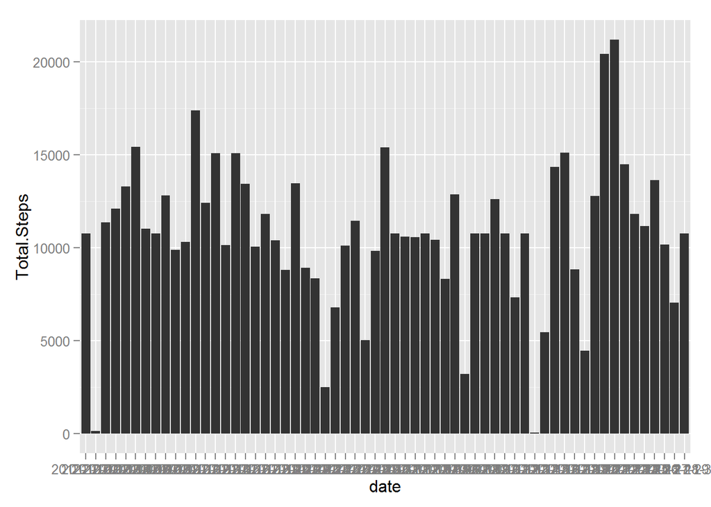

```r
# Prepare a histogram of the steps. Mising (NA) values have been imputed.
totalSteps <- ddply(activityDataNew,.(date), summarize, Total.Steps=sum(steps))
qplot(x=date,y=Total.Steps,data=totalSteps,geom="bar",
                 stat="identity")
```

```r
# Compute mean of total steps taken per day, removing NAs for a numeric result
mean(totalSteps$Total.Steps, na.rm=TRUE)
```

```
## [1] 10766.19
```

```r
# Compute median of total steps taken each day, removing NAs for a numeric result
median(totalSteps$Total.Steps,na.rm=TRUE)
```

```
## [1] 10766.19
```

As evident from the results, there is no difference in the means of total steps taken per day calculated before and after imputation of NAs. There is a minor difference in the medians calculated before and after imputation of NAs.

### Assessing differences in activity patterns in weekdays and weekends

We introduce a factor variable called ‘Day.Type’ in the new imputed dataset classifying the day as a weekday or weekend. We then prepare a panel plot to compare average steps taken in weekdays versus weekends.

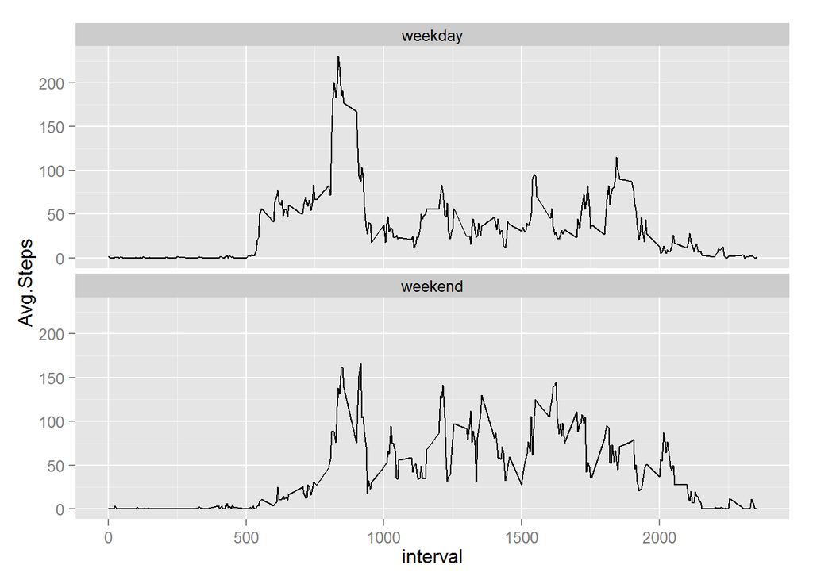

```r
# Introducing new factor variable to classify day as weekday or weekend
activityDataNew$Day.Type <- with(activityDataNew,ifelse(wday(activityDataNew$date)==1 | wday(activityDataNew$date)==7,"weekend","weekday"))
# Calculate average steps by interval taken across weekdays and weekends
avgSteps <- ddply(activityDataNew,.(interval,Day.Type), summarize,
                  Avg.Steps=mean(steps,na.rm=TRUE))
# Prepare panel plot to show average steps taken across weekdays and weekends
ggplot(avgSteps,aes(interval,Avg.Steps))+geom_line()+facet_grid(.~Day.Type) + facet_wrap(~Day.Type,ncol=1)
```

By looking at the plots for weekday and weekend we can see that the number of steps taken during earlier hours of the day in weekdays is more compared to early hours in the weekends. Specifically, the maximum average steps are taken in the 835 interval.